# Project Python Foundations: FoodHub Data Analysis

### Context

The number of restaurants in New York is increasing day by day. Lots of students and busy professionals rely on those restaurants due to their hectic lifestyles. Online food delivery service is a great option for them. It provides them with good food from their favorite restaurants. A food aggregator company FoodHub offers access to multiple restaurants through a single smartphone app.

The app allows the restaurants to receive a direct online order from a customer. The app assigns a delivery person from the company to pick up the order after it is confirmed by the restaurant. The delivery person then uses the map to reach the restaurant and waits for the food package. Once the food package is handed over to the delivery person, he/she confirms the pick-up in the app and travels to the customer's location to deliver the food. The delivery person confirms the drop-off in the app after delivering the food package to the customer. The customer can rate the order in the app. The food aggregator earns money by collecting a fixed margin of the delivery order from the restaurants.

### Objective

The food aggregator company has stored the data of the different orders made by the registered customers in their online portal. They want to analyze the data to get a fair idea about the demand of different restaurants which will help them in enhancing their customer experience. Suppose you are hired as a Data Scientist in this company and the Data Science team has shared some of the key questions that need to be answered. Perform the data analysis to find answers to these questions that will help the company to improve the business.

### Data Description

The data contains the different data related to a food order. The detailed data dictionary is given below.

### Data Dictionary

- order_id: Unique ID of the order
- customer_id: ID of the customer who ordered the food
- restaurant_name: Name of the restaurant
- cuisine_type: Cuisine ordered by the customer
- cost_of_the_order: Cost of the order
- day_of_the_week: Indicates whether the order is placed on a weekday or weekend (The weekday is from Monday to Friday and the weekend is Saturday and Sunday)
- rating: Rating given by the customer out of 5
- food_preparation_time: Time (in minutes) taken by the restaurant to prepare the food. This is calculated by taking the difference between the timestamps of the restaurant's order confirmation and the delivery person's pick-up confirmation.
- delivery_time: Time (in minutes) taken by the delivery person to deliver the food package. This is calculated by taking the difference between the timestamps of the delivery person's pick-up confirmation and drop-off information

### Let us start by importing the required libraries

```python
#Update PATH environment variable

#print current env PATH variable value
!printenv PATH

# Append /root/.local/bin to the existing path environment variable to get rid of these installation warnings - f2py, f2py3 and f2py3.10 are installed in '/root/.local/bin' which is not on PATH.
%env PATH=/opt/bin:/usr/local/nvidia/bin:/usr/local/cuda/bin:/usr/local/sbin:/usr/local/bin:/usr/sbin:/usr/bin:/sbin:/bin:/tools/node/bin:/tools/google-cloud-sdk/bin:/root/.local/bin
```

```
/opt/bin:/usr/local/nvidia/bin:/usr/local/cuda/bin:/usr/local/sbin:/usr/local/bin:/usr/sbin:/usr/bin:/sbin:/bin:/tools/node/bin:/tools/google-cloud-sdk/bin
env: PATH=/opt/bin:/usr/local/nvidia/bin:/usr/local/cuda/bin:/usr/local/sbin:/usr/local/bin:/usr/sbin:/usr/bin:/sbin:/bin:/tools/node/bin:/tools/google-cloud-sdk/bin:/root/.local/bin
```

```python
# Installing the libraries with the specified version.
#!pip install numpy==1.25.2 pandas==1.5.3 matplotlib==3.7.1 seaborn==0.13.1 -q --user
#To fix pip's dependency packages version errors pandas and matplot lib higher versions are installed.

!pip install numpy==1.25.2 pandas==2.2.2 matplotlib==3.8.0 seaborn==0.13.1 -q --user
```

```python
# View python version
!python --version
```

```
Python 3.10.12
```

```python
#View numpy version
!pip show numpy
```

[output not shown]

```python
#View pandas version
!pip show pandas
```

[output not shown]

```python
#View matplotlib version
!pip show matplotlib
```

```
Name: matplotlib
Version: 3.8.0
Summary: Python plotting package
Home-page: https://matplotlib.org
Author: John D. Hunter, Michael Droettboom
Author-email: matplotlib-users@python.org
License: PSF
Location: /usr/local/lib/python3.10/dist-packages
Requires: contourpy, cycler, fonttools, kiwisolver, numpy, packaging, pillow, pyparsing, python-dateutil
Required-by: arviz, bigframes, datascience, fastai, geemap, imgaug, matplotlib-venn, missingno, mlxtend, music21, plotnine, prophet, pycocotools, seaborn, wordcloud, yellowbrick
```

```python
#View seaborn version
!pip show seaborn
```

```
Name: seaborn
Version: 0.13.1
Summary: Statistical data visualization
Home-page:
Author:
Author-email: Michael Waskom <mwaskom@gmail.com>
License:
Location: /root/.local/lib/python3.10/site-packages
Requires: matplotlib, numpy, pandas
Required-by: missingno
```

**Note**: *After running the above cell, kindly restart the notebook kernel and run all cells sequentially from the start again.*

```python
# import libraries for data manipulation
import numpy as np
import pandas as pd

# import libraries for data visualization
import matplotlib.pyplot as plt
import seaborn as sns
import plotly.express as px

#supress the warning without needing to update Seaborn
import warnings
warnings.filterwarnings("ignore", category=FutureWarning)

# Command to tell Python to actually display the graphs
%matplotlib inline
```

### Understanding the structure of the data

```python
# import drive from Google Colab
from google.colab import drive
drive.mount('/content/drive')
```

```python
# read the data from drive.Load the dataset
df = pd.read_csv("/content/drive/My Drive/FoodHub Project/foodhub_order.csv")

#create a copy of the dataset that will be used for data manipulation and visualization
data = df.copy()
```

```python
# view the first 5 rows
data.head()
```

|  | order_id | customer_id | restaurant_name | cuisine_type | cost_of_the_order | day_of_the_week | rating | food_preparation_time | delivery_time |
| --- | --- | --- | --- | --- | --- | --- | --- | --- | --- |
| 0 | 1477147 | 337525 | Hangawi | Korean | 30.75 | Weekend | Not given | 25 | 20 |
| 1 | 1477685 | 358141 | Blue Ribbon Sushi Izakaya | Japanese | 12.08 | Weekend | Not given | 25 | 23 |
| 2 | 1477070 | 66393 | Cafe Habana | Mexican | 12.23 | Weekday | 5 | 23 | 28 |
| 3 | 1477334 | 106968 | Blue Ribbon Fried Chicken | American | 29.20 | Weekend | 3 | 25 | 15 |
| 4 | 1478249 | 76942 | Dirty Bird to Go | American | 11.59 | Weekday | 4 | 25 | 24 |

### **Question 1:** How many rows and columns are present in the data? [0.5 mark]

```python
# shape attribute gives the count of rows and columns
data.shape
```

```
(1898, 9)
```

#### **Observations:**

### There are **1898 rows and 9 columns** in this data set

### **Question 2:** What are the datatypes of the different columns in the dataset? (The info() function can be used) [0.5 mark]

```python
# Datatypes of diferrent columns in the dataset
df.info()
```

```
<class 'pandas.core.frame.DataFrame'>
RangeIndex: 1898 entries, 0 to 1897
Data columns (total 9 columns):
 #   Column                 Non-Null Count  Dtype
---  ------                 --------------  -----
 0   order_id               1898 non-null   int64
 1   customer_id            1898 non-null   int64
 2   restaurant_name        1898 non-null   object
 3   cuisine_type           1898 non-null   object
 4   cost_of_the_order      1898 non-null   float64
 5   day_of_the_week        1898 non-null   object
 6   rating                 1898 non-null   object
 7   food_preparation_time  1898 non-null   int64
 8   delivery_time          1898 non-null   int64
dtypes: float64(1), int64(4), object(4)
memory usage: 133.6+ KB
```

#### **Observations:**

### There are **float,int and object** types

### There are **4 categorical variables and 5 numerical variables** in the orders dataset

### order_id ,customer_id,food_preparation_time and delivery_time are integer values. cost_of_the_order is float type.

### restaurant name,cuisine_type,day_of_the_week,rating are object type.

### rating can be converted to float type

### **Question 3:** Are there any missing values in the data? If yes, treat them using an appropriate method. [1 mark]

```python
# find any missing values
df.isnull().sum()
```

|  | 0 |
| --- | --- |
| order_id | 0 |
| customer_id | 0 |
| restaurant_name | 0 |
| cuisine_type | 0 |
| cost_of_the_order | 0 |
| day_of_the_week | 0 |
| rating | 0 |
| food_preparation_time | 0 |
| delivery_time | 0 |

**dtype:** int64

#### **Observations:**

### There are **no missing values** in the data

### Rating is object type(string) . Rating with "Not given" value can be treated and converted to float.

```python
#Analyze rating object
data['rating'].apply(type).value_counts()
```

| rating | count |
| --- | --- |
| <class 'str'> | 1898 |

**dtype:** int64

```python
#get uniques value of rating
data['rating'].unique()
```

```
array(['Not given', '5', '3', '4'], dtype=object)
```

```python
#rating can be converted to float type and the "Not given" string can be changed to NAN

data['rating'] = data['rating'].replace(['Not given'],np.nan)

print(data['rating'].value_counts())

#convert rating to float type
data['rating'] = data['rating'].astype(float)

#check the type of 'rating' column being converted to float
data.info()
```

```
rating
5    588
4    386
3    188
Name: count, dtype: int64
<class 'pandas.core.frame.DataFrame'>
RangeIndex: 1898 entries, 0 to 1897
Data columns (total 9 columns):
 #   Column                 Non-Null Count  Dtype
---  ------                 --------------  -----
 0   order_id               1898 non-null   int64
 1   customer_id            1898 non-null   int64
 2   restaurant_name        1898 non-null   object
 3   cuisine_type           1898 non-null   object
 4   cost_of_the_order      1898 non-null   float64
 5   day_of_the_week        1898 non-null   object
 6   rating                 1162 non-null   float64
 7   food_preparation_time  1898 non-null   int64
 8   delivery_time          1898 non-null   int64
dtypes: float64(2), int64(4), object(3)
memory usage: 133.6+ KB
```

### **Question 4:** Check the statistical summary of the data. What is the minimum, average, and maximum time it takes for food to be prepared once an order is placed? [2 marks]

```python
# statistical summary of the data
df.describe(include='all').T
```

|  | count | unique | top | freq | mean | std | min | 25% | 50% | 75% | max |
| --- | --- | --- | --- | --- | --- | --- | --- | --- | --- | --- | --- |
| order_id | 1898.0 | NaN | NaN | NaN | 1477495.5 | 548.049724 | 1476547.0 | 1477021.25 | 1477495.5 | 1477969.75 | 1478444.0 |
| customer_id | 1898.0 | NaN | NaN | NaN | 171168.478398 | 113698.139743 | 1311.0 | 77787.75 | 128600.0 | 270525.0 | 405334.0 |
| restaurant_name | 1898 | 178 | Shake Shack | 219 | NaN | NaN | NaN | NaN | NaN | NaN | NaN |
| cuisine_type | 1898 | 14 | American | 584 | NaN | NaN | NaN | NaN | NaN | NaN | NaN |
| cost_of_the_order | 1898.0 | NaN | NaN | NaN | 16.498851 | 7.483812 | 4.47 | 12.08 | 14.14 | 22.2975 | 35.41 |
| day_of_the_week | 1898 | 2 | Weekend | 1351 | NaN | NaN | NaN | NaN | NaN | NaN | NaN |
| rating | 1898 | 4 | Not given | 736 | NaN | NaN | NaN | NaN | NaN | NaN | NaN |
| food_preparation_time | 1898.0 | NaN | NaN | NaN | 27.37197 | 4.632481 | 20.0 | 23.0 | 27.0 | 31.0 | 35.0 |
| delivery_time | 1898.0 | NaN | NaN | NaN | 24.161749 | 4.972637 | 15.0 | 20.0 | 25.0 | 28.0 | 33.0 |

#### **Observations:**

### It takes **minimum 20 minutes , maximum 35 minutes,and an average of 27.37 minutes** for the food to be prepared once an order is placed (food_preparation_time)

### **Question 5:** How many orders are not rated? [1 mark]

```python
# List the count of all ratings
#df is original data with rating having "Not Given" values and it represents orders that are not rated
print(df['rating'].value_counts())

# Or using NAN
print("Orders that are not rated:",data['rating'].isna().sum())
```

```
rating
Not given    736
5            588
4            386
3            188
Name: count, dtype: int64
Orders that are not rated: 736
```

#### **Observations:**

### There are **736** orders that are not rated

### Exploratory Data Analysis (EDA)

### Univariate Analysis

### **Question 6:** Explore all the variables and provide observations on their distributions. (Generally, histograms, boxplots, countplots, etc. are used for univariate exploration.) [9 marks]

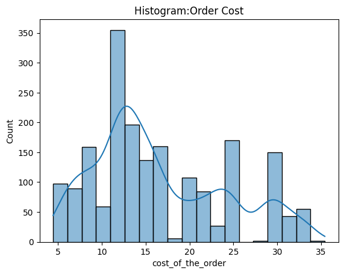

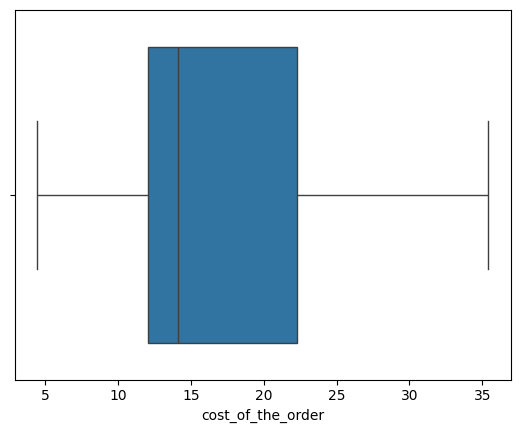

```python
# Histogram
plt.title('Histogram:Order Cost')
sns.histplot(data=data,x='cost_of_the_order',kde=True)
plt.show()

#Box Plot
sns.boxplot(data=data,x='cost_of_the_order')
plt.show()
```

### **Observations**

### Cost of the order varies from 4.5 to 35.

### Cost of the Order histogram is skewed to the right has a large number of occurrences on the left side of the plot and a few on the right side of the plot

### In the boxplot, median is closer to the left of the box and the whisker is shorter on the left end of the box, hence the distribution is positively skewed (skewed right).

### Average cost of the order is 16.5

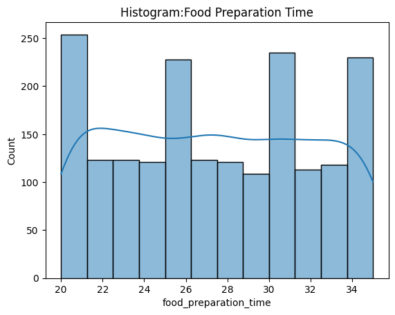

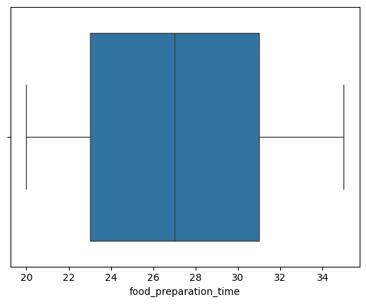

```python
# Histogram
plt.title('Histogram:Food Preparation Time')
sns.histplot(data=data,x='food_preparation_time',kde=True)
plt.show()

#Box Plot
sns.boxplot(data=data,x='food_preparation_time')
plt.show()
```

#### **Observations**

### It takes minimum 20 minutes , maximum 35 minutes,and an average of 27 minutes for the food to be prepared once an order is placed (food_preparation_time)

### Distribution is almost symmetrical

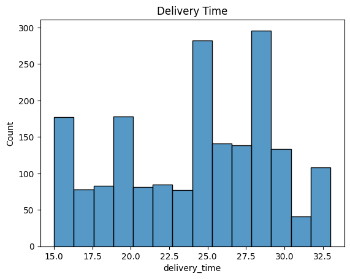

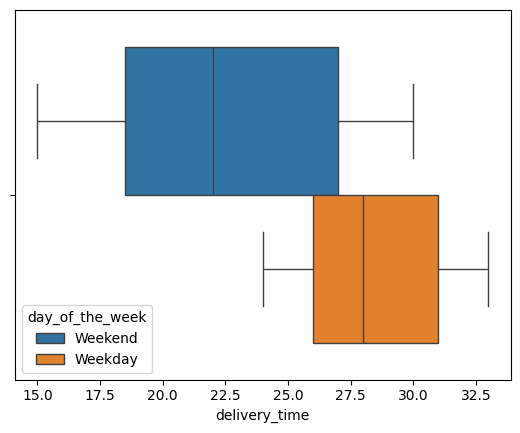

```python
#Histogram
plt.title('Delivery Time')

#Hist Plot
ax = sns.histplot(data=data,x='delivery_time')
plt.show()
#Box Plot
sns.boxplot(data=data,x='delivery_time',hue='day_of_the_week')
plt.show()
```

### Weekends delivery time is right skewed

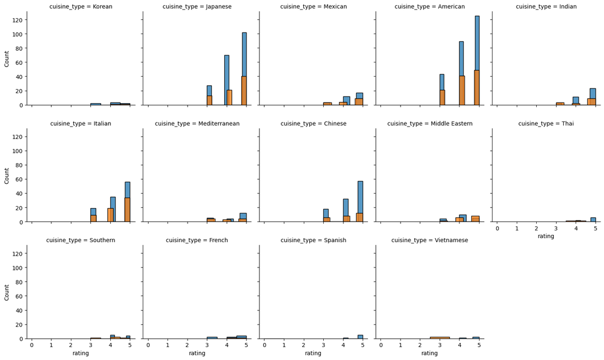

```python
#sub plots of cuisine type and rating
g = sns.FacetGrid(data, col="cuisine_type",hue="day_of_the_week",col_wrap=5)
g.map(sns.histplot, "rating");
```

#### **Observations**

### American,Japanese,Italian has more orders with higher ratings

```
day_of_the_week
Weekend    1351
Weekday     547
Name: count, dtype: int64
```

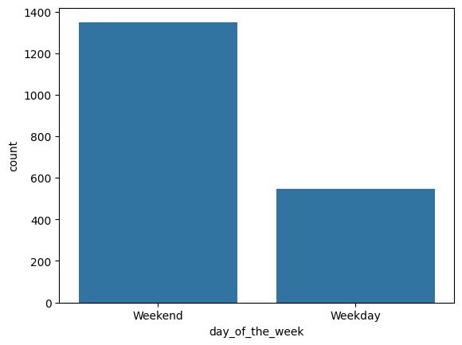

```python
#Number of orders info by day of the week
print(data.day_of_the_week.value_counts())

#count of orders countplot
sns.countplot(data=data,x='day_of_the_week')
plt.show()
```

#### **Observations**

### There are 1351 orders during weekend and 547 orders during weekday

#### There are more orders during the weekend than weekday

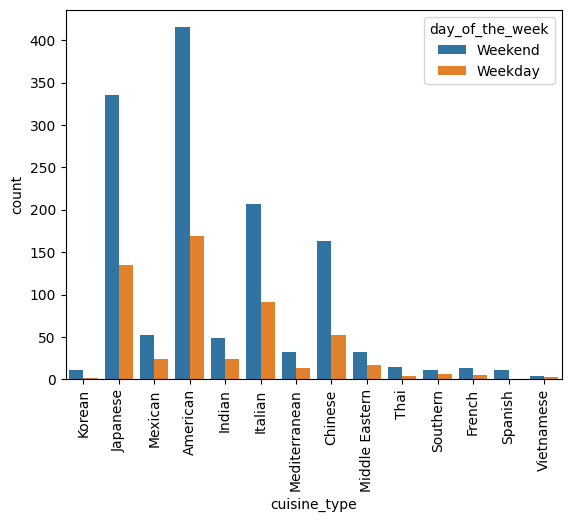

```python
#Count Plot of cuisine types
sns.countplot(data=data,x='cuisine_type',hue='day_of_the_week')
plt.xticks(rotation=90)
plt.show()
```

### **Observations**

### American cuisine type is top both during weekday and weekend

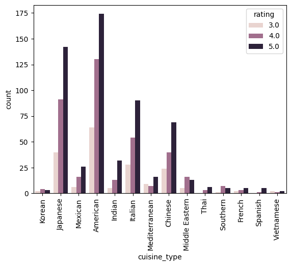

```python
#cuisine type ratings
sns.countplot(data=data,x='cuisine_type',hue='rating')
plt.xticks(rotation=90)
plt.show()
```

#### **Observations**

American has top rating

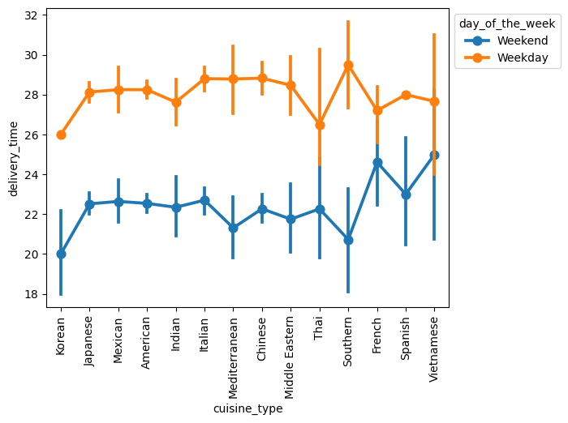

```python
#Time taken to deliver for each cuisine type
ax = sns.pointplot(data=data,x='cuisine_type',y='delivery_time',hue='day_of_the_week')
sns.move_legend(ax, "upper left", bbox_to_anchor=(1, 1))
plt.xticks(rotation=90)
plt.show()
```

```python
#Frequently ordering customers: Top 5 customers
data.customer_id.value_counts().head()
```

| customer_id | count |
| --- | --- |
| 52832 | 13 |
| 47440 | 10 |
| 83287 | 9 |
| 250494 | 8 |
| 259341 | 7 |

**dtype:** int64

```python
import plotly.io as pio
pio.renderers.default = "notebook_connected"

#Analyse top restaurants graphically for each cuisine type graphically
his = px.histogram(data,x='restaurant_name',color='cuisine_type')
his.show()
```

[interactive chart not shown]

### **Observations**

### Shake Shack is top American restaurant by order count

### Blue Ribbon Sushi is top Japanese restaurant

### The Meatball Shop Top Italian restaurant.It is also an American cuisine type.

### In Chinese cuisine type ,RedFarm Broadway has more orders.

### In Indian cusisine type, Tamrind TriBeCa has more orders

```python
#show top 5 rated restaturants
data.groupby('restaurant_name')['rating'].mean().sort_values(ascending=False).head()
```

| restaurant_name | rating |
| --- | --- |
| 'wichcraft | 5.0 |
| Ravagh Persian Grill | 5.0 |
| Chola Eclectic Indian Cuisine | 5.0 |
| Chote Nawab | 5.0 |
| Junoon | 5.0 |

**dtype:** float64

### **Question 7**: Which are the top 5 restaurants in terms of the number of orders received? [1 mark]

```python
# top 5 restaurants by orders count
data.restaurant_name.value_counts().head()
```

| restaurant_name | count |
| --- | --- |
| Shake Shack | 219 |
| The Meatball Shop | 132 |
| Blue Ribbon Sushi | 119 |
| Blue Ribbon Fried Chicken | 96 |
| Parm | 68 |

**dtype:** int64

#### Observations:

### Top 5 restaurants in terms of orders received are Shake Shack, The Meatball Shop,Blue Ribbon Sushi,Blue Ribbon Fried Chicken and Parm

### **Question 8**: Which is the most popular cuisine on weekends? [1 mark]

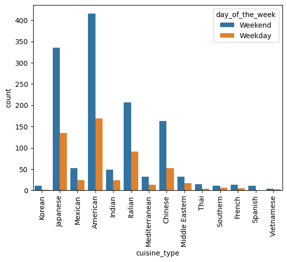

| day_of_the_week | cuisine_type | count |
| --- | --- | --- |
| Weekday | American | 169 |
|  | Japanese | 135 |
|  | Italian | 91 |
|  | Chinese | 52 |
|  | Indian | 24 |
|  | Mexican | 24 |
|  | Middle Eastern | 17 |
|  | Mediterranean | 14 |
|  | Southern | 6 |
|  | French | 5 |
|  | Thai | 4 |
|  | Vietnamese | 3 |
|  | Korean | 2 |
|  | Spanish | 1 |
| Weekend | American | 415 |
|  | Japanese | 335 |
|  | Italian | 207 |
|  | Chinese | 163 |
|  | Mexican | 53 |
|  | Indian | 49 |
|  | Mediterranean | 32 |
|  | Middle Eastern | 32 |
|  | Thai | 15 |
|  | French | 13 |
|  | Korean | 11 |
|  | Southern | 11 |
|  | Spanish | 11 |
|  | Vietnamese | 4 |

**dtype:** int64

```python
# Count plot to find the most popular cuisine
sns.countplot(data=data,x='cuisine_type',hue='day_of_the_week')
plt.xticks(rotation=90)
plt.show()

#Using value count to find the most popular cuisine
data.groupby('day_of_the_week')['cuisine_type'].value_counts()
```

#### **Observations:**

### Most popular cuisine on weekends is **"American"**

### There are around 415 orders for American cuisine.

### **Question 9**: What percentage of the orders cost more than 20 dollars? [2 marks]

```python
# Write the code here
total = data.shape[0]
orders_greater_than_20 = data.loc[data['cost_of_the_order']>20,'cost_of_the_order'].count()
percentage = orders_greater_than_20/total*100
print(f'{percentage:.2f}% of the orders cost more than 20 dollars')
```

```
29.24% of the orders cost more than 20 dollars
```

#### **Observations:**

### **29.24%** of the orders cost more than 20 dollars

### **Question 10**: What is the mean order delivery time? [1 mark]

```python
# mean order delivery time using describe and finding mean value
data['delivery_time'].describe()
```

|  | delivery_time |
| --- | --- |
| count | 1898.000000 |
| mean | 24.161749 |
| std | 4.972637 |
| min | 15.000000 |
| 25% | 20.000000 |
| 50% | 25.000000 |
| 75% | 28.000000 |
| max | 33.000000 |

**dtype:** float64

```python
#mean order delivery time using mean function
data['delivery_time'].mean()
print(f'The mean order delivery time is {data["delivery_time"].mean()} minutes')
```

```
The mean order delivery time is 24.161749209694417 minutes
```

#### **Observations:**

### The mean order delivery time is **24.161749** minutes

### **Question 11:** The company has decided to give 20% discount vouchers to the top 3 most frequent customers. Find the IDs of these customers and the number of orders they placed. [1 mark]

```python
# top 3 most frequent customers
data['customer_id'].value_counts().head(3)
pd.DataFrame({'Number of orders':data['customer_id'].value_counts().head(3)})
```

| customer_id | Number of orders |
| --- | --- |
| 52832 | 13 |
| 47440 | 10 |
| 83287 | 9 |

#### **Observations:**

### Top 3 customers ,their ids and the number of orders they have placed are shown in above dataframe. There are 13 orders placed by the top 1 customer.

### Multivariate Analysis

### **Question 12**: Perform a multivariate analysis to explore relationships between the important variables in the dataset. (It is a good idea to explore relations between numerical variables as well as relations between numerical and categorical variables) [10 marks]

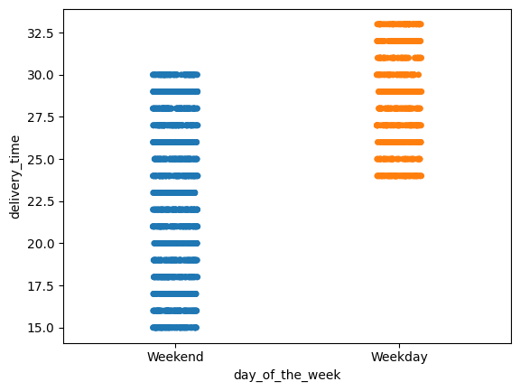

| day_of_the_week | count | mean | std | min | 25% | 50% | 75% | max |
| --- | --- | --- | --- | --- | --- | --- | --- | --- |
| Weekday | 547.0 | 28.340037 | 2.891428 | 24.0 | 26.0 | 28.0 | 31.0 | 33.0 |
| Weekend | 1351.0 | 22.470022 | 4.628938 | 15.0 | 18.5 | 22.0 | 27.0 | 30.0 |

```python
sns.stripplot(data=data,x='day_of_the_week',y='delivery_time',hue='day_of_the_week')
plt.show()

data.groupby('day_of_the_week')['delivery_time'].describe()
```

#### **Observations**

### Mean delivery time during weekday is higher than delivery time during weekend

### It takes 24mins to 33mins to deliver food during weekday

### It takes 15mins to 30mins to deliver food during weekend

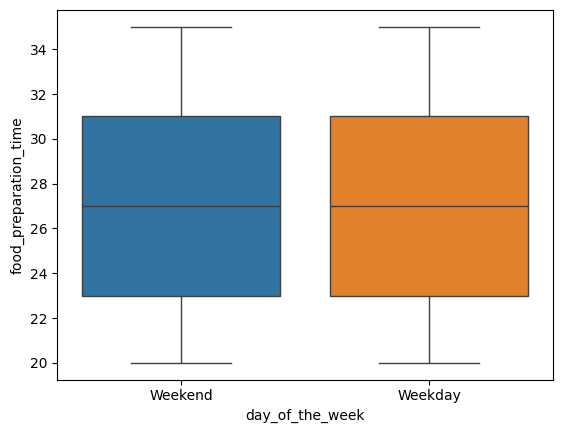

| day_of_the_week | count | mean | std | min | 25% | 50% | 75% | max |
| --- | --- | --- | --- | --- | --- | --- | --- | --- |
| Weekday | 547.0 | 27.212066 | 4.708616 | 20.0 | 23.0 | 27.0 | 31.0 | 35.0 |
| Weekend | 1351.0 | 27.436714 | 4.601476 | 20.0 | 23.0 | 27.0 | 31.0 | 35.0 |

```python
#Food preparation time
sns.boxplot(data=data,x='day_of_the_week',y='food_preparation_time',hue='day_of_the_week')
plt.show()
data.groupby('day_of_the_week')['food_preparation_time'].describe()
```

#### **Observations:**

### Food preparation time varies from 20mins - 35mins irrespective of the day of the week

```python
#Orders and days of the week analysis
data.groupby('day_of_the_week')['order_id'].count()
pd.DataFrame({'Number of orders': data.groupby('day_of_the_week')['order_id'].count()})
```

| day_of_the_week | Number of orders |
| --- | --- |
| Weekday | 547 |
| Weekend | 1351 |

#### **Observations**

### More orders are placed during weekend

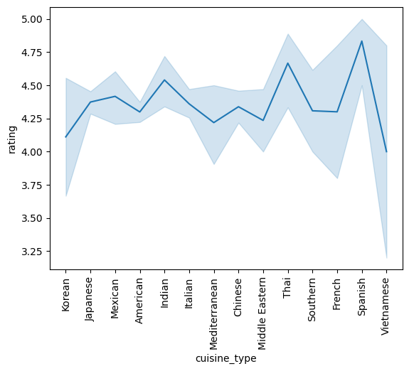

```python
#cuisine type ratings
sns.lineplot(data=data,x='cuisine_type',y='rating')
plt.xticks(rotation=90)
plt.show()
```

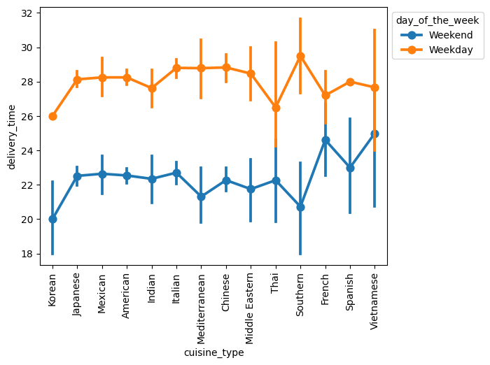

```python
#Time taken to deliver for each cuisine type
ax = sns.pointplot(data=data,x='cuisine_type',y='delivery_time',hue='day_of_the_week')
sns.move_legend(ax, "upper left", bbox_to_anchor=(1, 1))
plt.xticks(rotation=90)
plt.show()
```

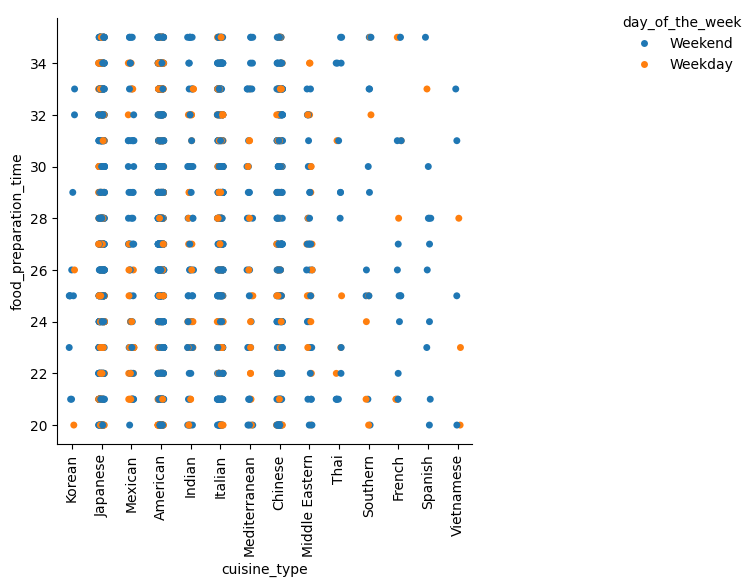

```python
#Time taken to prepare food for each cuisine type
ax = sns.catplot(data=data,x='cuisine_type',y='food_preparation_time',hue='day_of_the_week')
sns.move_legend(ax, "upper left", bbox_to_anchor=(1, 1))
plt.xticks(rotation=90)
plt.show()
```

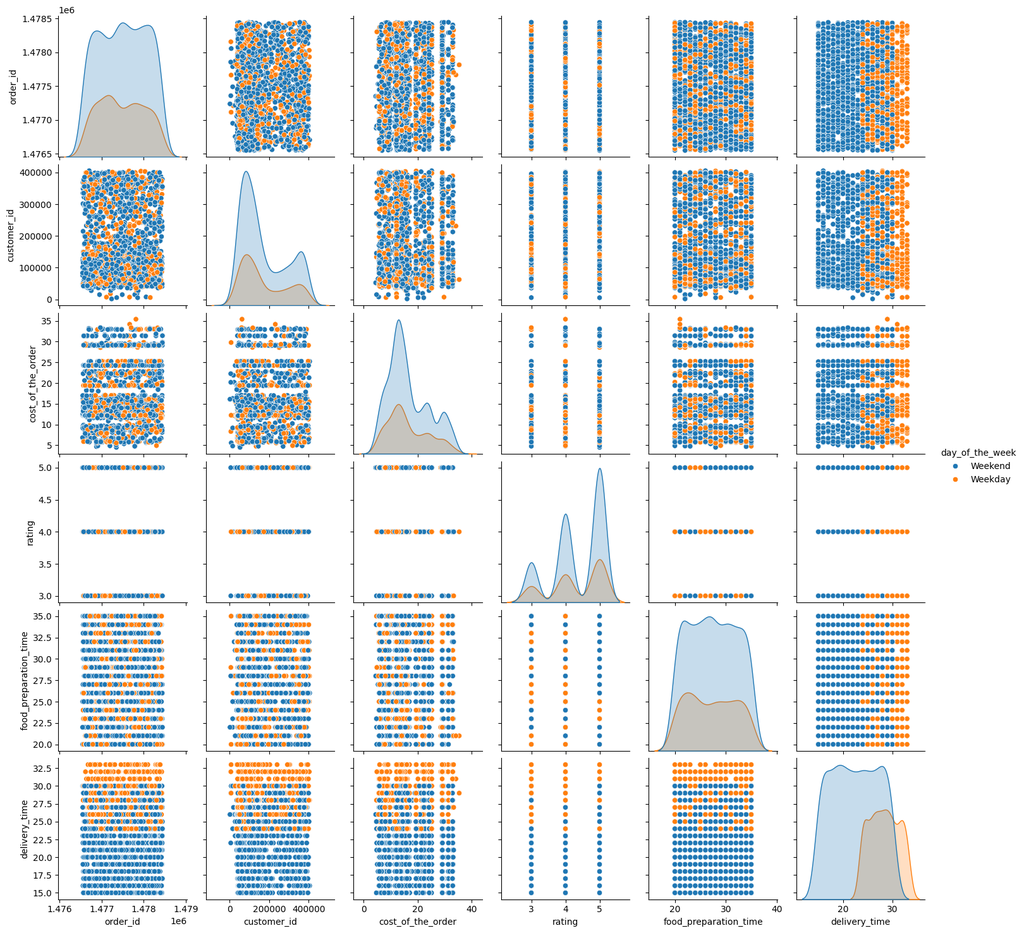

```python
# Analyse the relationship between numerical variables using pairplot
sns.pairplot(data=data,hue='day_of_the_week')
plt.show()
```

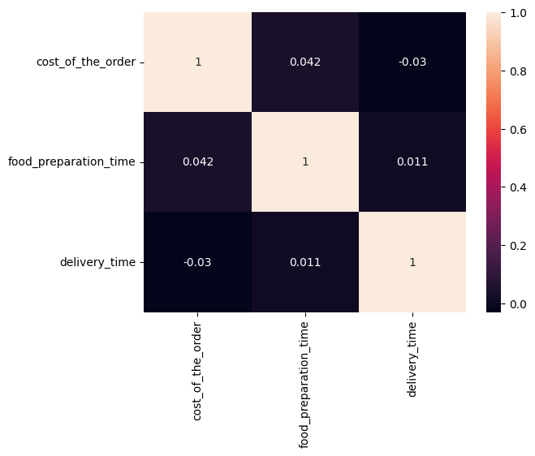

```python
###Analyse correlation between the numerical variables
numerical_columns  = ['cost_of_the_order','food_preparation_time','delivery_time']
sns.heatmap(data[numerical_columns].corr(),annot=True)
plt.show()
```

##### **Observations**

### Not much correlation between the numerical variables

### **Question 13:** The company wants to provide a promotional offer in the advertisement of the restaurants. The condition to get the offer is that the restaurants must have a rating count of more than 50 and the average rating should be greater than 4. Find the restaurants fulfilling the criteria to get the promotional offer. [3 marks]

```python
# Restaurant's rating count greater than 50 and average rating greater than 4

# Create a DataFrame with restaurant rating counts and means
restaurant_ratings = data.groupby('restaurant_name')['rating'].agg(['count', 'mean'])

print(restaurant_ratings)

for index, restaurant in restaurant_ratings.iterrows():
    # Iterate over each row in the DataFrame
    if restaurant['count'] > 50 and restaurant['mean'] > 4:
        # Check both conditions: rating count and average rating
        print(f"Restaurant {index} will receive promotional offer")
```

```
                  count      mean
restaurant_name
'wichcraft            1  5.000000
12 Chairs             2  4.500000
5 Napkin Burger       2  4.000000
67 Burger             1  5.000000
Alidoro               0       NaN
...                 ...       ...
Zero Otto Nove        1  4.000000
brgr                  1  3.000000
da Umberto            1  5.000000
ilili Restaurant     13  4.153846
indikitch             2  4.500000

[178 rows x 2 columns]
Restaurant Blue Ribbon Fried Chicken will receive promotional offer
Restaurant Blue Ribbon Sushi will receive promotional offer
Restaurant Shake Shack will receive promotional offer
Restaurant The Meatball Shop will receive promotional offer
```

#### **Observations:**

### There are 4 restaurants that have a rating count more than 50 and average rating greater than 4 that will receive promotional offer.

### Blue Ribbon Fried Chicken,Blue Ribbon Sushi,Shake Shack,The Meatball Shop

### **Question 14:** The company charges the restaurant 25% on the orders having cost greater than 20 dollars and 15% on the orders having cost greater than 5 dollars. Find the net revenue generated by the company across all orders. [3 marks]

```python
# Company charges
#charge 25% on the orders having cost greater than 20 dollars
charge25 = data.loc[data['cost_of_the_order']>20,'cost_of_the_order']*0.25
print(charge25)
#charge 15% on the orders having cost greater than 20 dollars
charge15 = data.loc[data['cost_of_the_order']>5,'cost_of_the_order']*0.15

#net revenuw generated by the company
net_revenue= charge25.sum()+charge15.sum()
print(f'The net revenue generated by the company across all orders is {net_revenue}')
```

```
0       7.6875
3       7.3000
5       6.3050
12      6.0750
17      8.2575
         ...
1884    7.8575
1885    7.2625
1892    7.2875
1893    5.5775
1895    6.3050
Name: cost_of_the_order, Length: 555, dtype: float64
The net revenue generated by the company across all orders is 8379.539499999999
```

### **Question 15:** The company wants to analyze the total time required to deliver the food. What percentage of orders take more than 60 minutes to get delivered from the time the order is placed? (The food has to be prepared and then delivered.) [2 marks]

```python
#analyse total time required to deliver the food

#Find the total number of orders
total_order = data.shape[0]
print("Total number of orders:",total_order)

#count the orders that take more than 60 minutes to get delivered(preparation time and delivery time)
orders_count = data.loc[data['delivery_time']+data['food_preparation_time']>60,'order_id'].count()
print("Number of orders that takes more than 60 minutes:",orders_count,"orders")
#prep_time = data.loc[data['food_preparation_time'],'food_preparation_time']  data.loc[data['delivery_time'],'delivery_time']

percentage = orders_count/total_order*100
print(f'{percentage:.2f}% of orders take more than 60 minutes to get delivered')
```

```
Total number of orders: 1898
Number of orders that takes more than 60 minutes: 200 orders
10.54% of orders take more than 60 minutes to get delivered
```

#### **Observations:**

### There are around 200 orders that takes more than 60mins to get delivered from the time the order is placed. This is 10.54% of orders takes more than 60 minutes to get delivered from the time the order is placed(includes the food preparation time and delivery time).

### **Question 16:** The company wants to analyze the delivery time of the orders on weekdays and weekends. How does the mean delivery time vary during weekdays and weekends? [2 marks]

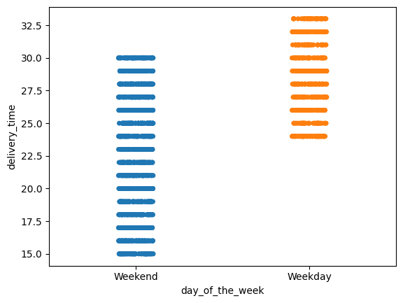

| day_of_the_week | count | mean | std | min | 25% | 50% | 75% | max |
| --- | --- | --- | --- | --- | --- | --- | --- | --- |
| Weekday | 547.0 | 28.340037 | 2.891428 | 24.0 | 26.0 | 28.0 | 31.0 | 33.0 |
| Weekend | 1351.0 | 22.470022 | 4.628938 | 15.0 | 18.5 | 22.0 | 27.0 | 30.0 |

```python
# Analysis in Question 12
sns.stripplot(data=data,x='day_of_the_week',y='delivery_time',hue='day_of_the_week')
plt.show()

#Delivery Time group by day_of_the_week
data.groupby('day_of_the_week')['delivery_time'].describe()
```

#### Observations:

### Mean Delivery time during weekday is higher than the mean delivery time during weekend. It takes 24mins(min value) to 33mins(max value) to deliver food during weekday.It takes 15mins to 30mins to deliver food during weekend.

### Mean Delivery time during weekday is 28.3mins and during weekend it is 22.47mins.

### Conclusion and Recommendations

### **Question 17:** What are your conclusions from the analysis? What recommendations would you like to share to help improve the business? (You can use cuisine type and feedback ratings to drive your business recommendations.) [6 marks]

### Conclusions:

- Mean Delivery time during weekday is higher than the mean delivery time during weekend. It takes 24mins to 33mins to deliver food during weekday.It takes 15mins to 30mins to deliver food during weekend.

Mean Delivery time during weekday is 28.3mins and during weekend it is 22.47mins.

- Food preparation time varies from 20mins - 35mins irrespective of the day of the week
- Out of 1898 orders, 736 orders are not rated. 39% of data does not have rating which makes it challenging to gain insight on the customer experience for those restaurants.
- Out of 1898 orders,584 orders are from American cuisine. 30.76% of orders are American cuisine type.
- Shake Shack,The Meatball Shop,Blue Ribbon Sushi are the top 3 restaurants receiving orders.
- Witchcraft,Ravagh Persian Grill,Chola Eclectic Indian Cuisine,Chote Nawab,Junoon have received the highest ratings.
- 10.54% of orders take more than 60 minutes to get delivered(food preparation time and delivery time).89.46% of the orders takes less than 60 mins to get delivered from the time order is placed.
- 71.2% of the orders are made during the weekend.

### Recommendations:

- Implement measures to reward the restaurants with top ratings.This will encourage the restaurants to maintain the quality with increased customer ratings.
- Implement strategies to encourage customers to rate their experience and also provide incentives to customer to motivate them to provide feedback . Having accurate and filled rating data will help to gain insight on customer experience
- Implement strategies to promote cuisine types that has lowest customer orders like Vietnamese,Korean,Southern,Spanish,Thai.
- Come up with weekday promotions for the food orders so the number of orders during weekdays can be increased.